# Homework

Xinrong Xiang

2021-12-16

**2021-09-16** ## Question Use knitr to produce at least 3 examples(texts,figures,tables). ## Answer 1.texts

```r
#print('Hello World!')
```

2.figures

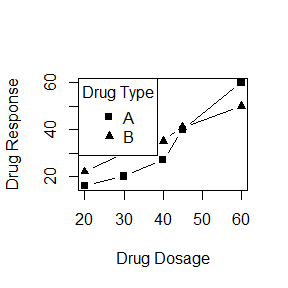

```r
dosage <- c(20, 30, 40, 45, 60)
drugA <- c(16, 20, 27, 40, 60)
drugB <- c(22, 30, 35, 41, 50 )
plot(dosage,drugA,type = 'b',pch=15,xlab="Drug Dosage", ylab="Drug Response")
lines(dosage, drugB, type="b",pch=17)
legend("topleft", title="Drug Type", c("A","B"),pch=c(15, 17))
```

3.tables

```r
knitr::kable(head(mtcars))
```

|  | mpg | cyl | disp | hp | drat | wt | qsec | vs | am | gear | carb |
| --- | --- | --- | --- | --- | --- | --- | --- | --- | --- | --- | --- |
| Mazda RX4 | 21.0 | 6 | 160 | 110 | 3.90 | 2.620 | 16.46 | 0 | 1 | 4 | 4 |
| Mazda RX4 Wag | 21.0 | 6 | 160 | 110 | 3.90 | 2.875 | 17.02 | 0 | 1 | 4 | 4 |
| Datsun 710 | 22.8 | 4 | 108 | 93 | 3.85 | 2.320 | 18.61 | 1 | 1 | 4 | 1 |
| Hornet 4 Drive | 21.4 | 6 | 258 | 110 | 3.08 | 3.215 | 19.44 | 1 | 0 | 3 | 1 |
| Hornet Sportabout | 18.7 | 8 | 360 | 175 | 3.15 | 3.440 | 17.02 | 0 | 0 | 3 | 2 |
| Valiant | 18.1 | 6 | 225 | 105 | 2.76 | 3.460 | 20.22 | 1 | 0 | 3 | 1 |

**2021-09-23** ## Question Exercises 3.4, 3.11, and 3.20 (pages 94-96, Statistical Computating with R) ## Answer 1: The Rayleigh density is $\frac{x}{\sigma^2}\exp (-\frac{x^2}{2\sigma^2}), x ≥ 0,\sigma > 0$. Develop an algorithm to generate random samples from a Rayleigh($\sigma$) distribution. Generate Rayleigh($\sigma$) samples for several choices of $\sigma > 0$ and check that the mode of the generated samples is close to the theoretical mode $\sigma$ (check the histogram).

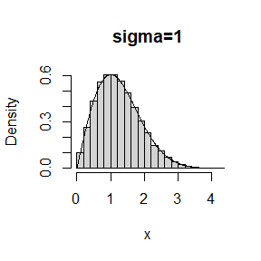

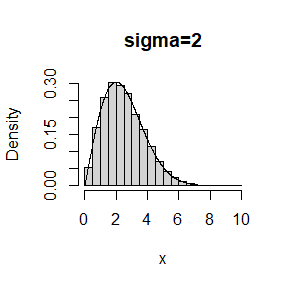

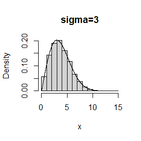

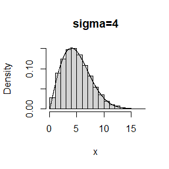

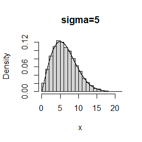

```r
rRayleigh=function(n,sigma){
  u <- runif(n)
  x <- (-2*sigma^2*log(1-u))^{1/2}
  #F(x)=1-e^(-x^2/2*sigma^(1/2)), 0<=x<=1
hist(x, prob = TRUE,main =paste('sigma=',as.character(sigma),sep=''))
  y <- seq(0,sigma*5, .01)
  lines(y,(y/sigma^2)*exp(-(1/2)*y^2/sigma^2))
}
for (i in 1:5) {
  rRayleigh(1e4,i)
}
```

2.Generate a random sample of size 1000 from a normal location mixture. Thecomponents of the mixture have N(0, 1) and N(3, 1) distributions with mixing probabilities p1 and p2 = 1 - p1. Graph the histogram of the sample with density superimposed, for p1 = 0.75. Repeat with different values for p1 and observe whether the empirical distribution of the mixture appears to be bimodal. Make a conjecture about the values of p1 that produce bimoda mixtures.

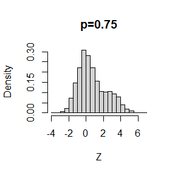

```r
Mix<-function(n,p){
  X1 <- rnorm(n)
  X2 <- rnorm(n,3,1)
  r <- sample(c(0,1),n,replace=TRUE,prob = c(1-p,p))
  Z <- r*X1+(1-r)*X2
  hist(Z,probability = TRUE,main = paste('p=',as.character(p),sep=''))

}
Mix(1e4,0.75)
```

```r
for (i in seq(0.1,0.9,0.1)){
  Mix(1e4,i)
}
```

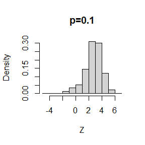

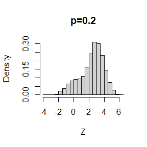

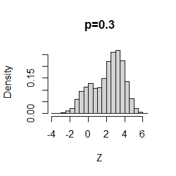

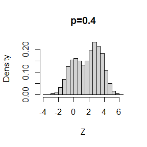

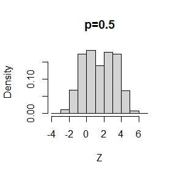

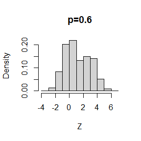

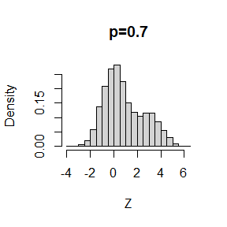

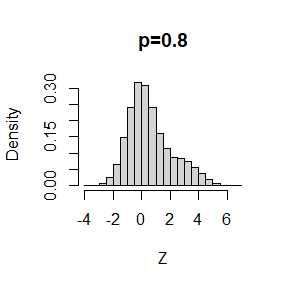

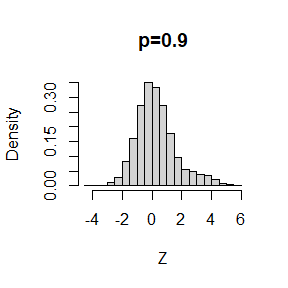

My conjecture: When p1=0.5, the empirical distribution of the mixture appears to be bimodal

3: A compound Poisson process is a stochastic process $\{X(t), t ≥ 0\}$ that can be represented as the random sum $X(t) = \sum_{i=1}^{N(t)} Y_i, t ≥ 0$, where $\{N(t), t ≥ 0\}$ is a Poisson process and $Y_1, Y_2,...$ are iid and independent of $\{N(t), t ≥ 0\}$.Write a program to simulate a compound Poisson(λ)–Gamma process (Y has a Gamma distribution). Estimate the mean and the variance of X(10) for several choices of the parameters and compare with the theoretical values. Hint: Show that $E[X(t)]$ = $λtE[Y_1]$ and $Var(X(t))=λtE[{Y_1}^2 ]$.

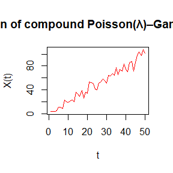

```r
pgp=function(lambda,a,b,t){

  N=rpois(1,lambda*t)
  y<-numeric(length = N)
  for (i in 1:N) {
    y[i]<-rgamma(1,a,b)
  }
  Xt<-sum(y)
  return(Xt)
}

#lamda=3,alpha=2,beta=3
pgpx<-function(x){
  Z<-numeric(length = x)
  for (i in 1:x) {
    Z[i]<-pgp(3,2,3,i)
  }
  return(Z)
}

pgp50<-pgpx(50)
m<-seq(1,50,1)
plot(m,pgp50,type ="l",col="red",xlab='t',ylab='X(t)',main = 'Smulation of compound Poisson(λ)–Gamma process')
```

```r
#Estimate the mean and the variance of X(10) for
#several choices of the parameters and compare with the theoretical values.
test<-function(l,a,b){
  x1<-numeric(length = 10)
   for (i in 1:10) {
      x1[i]<-pgp(l,a,b,10)
    }
   m1<-mean(x1)
   mt1<-l*10*(a/b)
   v1<-var(x1)
   vt1<-l*10*(a/(b^2)+(a/b)^2)
   print(paste("empirical mean is ",m1))
   print(paste("theoretical mean is",mt1))
   print(paste("empirical variance is ",v1))
   print(paste("theoretical variance is",vt1))
}

#lamda=3,alpha=2,gamma=3,t=10
test(3,2,3)
```

```
## [1] "empirical mean is  20.2185183968275"
## [1] "theoretical mean is 20"
## [1] "empirical variance is  26.3533051695768"
## [1] "theoretical variance is 20"
```

```r
#lamda=4,alpha=5,gamma=6,t=10
test(4,5,6)
```

```
## [1] "empirical mean is  32.7123431570753"
## [1] "theoretical mean is 33.3333333333333"
## [1] "empirical variance is  26.5969793263627"
## [1] "theoretical variance is 33.3333333333333"
```

**2021-09-30** ## Question Exercises 5.4, 5.9, 5.13 and 5.14 (pages 149-151, Statistical Computating with R)

1.Write a function to compute a Monte Carlo estimate of the Beta(3, 3) cdf, and use the function to estimate F(x) for x = 0.1, 0.2, . . . , 0.9. Compare the estimates with the values returned by the pbeta function in R.

```r
m <- 1e4;
mybetacdf<-function(x){
  t <- runif(m, min=0, max=x)
  theta.hat <- mean((1/beta(3,3))*t^2*(1-t)^2) * x
  return(theta.hat)
}

for (i in seq(0.1,0.9,0.1)) {
  print(c(mybetacdf(i),pbeta(i,3,3)))
}
```

```
## [1] 0.008574625 0.008560000
## [1] 0.05808867 0.05792000
## [1] 0.1635283 0.1630800
## [1] 0.3136902 0.3174400
## [1] 0.5006419 0.5000000
## [1] 0.6800563 0.6825600
## [1] 0.8338104 0.8369200
## [1] 0.9335486 0.9420800
## [1] 0.9875856 0.9914400
```

2.The Rayleigh density is $\frac{x}{\sigma^2}\exp (-\frac{x^2}{2\sigma^2}), x ≥ 0,\sigma > 0$.Implement a function to generate samples from a Rayleigh(σ) distribution, using antithetic variables. What is the percent reduction in variance of $\frac{X+X'}{2}$ compared with $\frac{X_1+X_2}{2}$ for independent $X_1$, $X_2$?

```r
set.seed(1234)
MC.Phi <- function(sigma, R = 10000, antithetic = TRUE) {
  u <- runif(R/2,0,1)
  if (!antithetic) v <- runif(R/2) else v <- 1 - u
  u <- c(u, v)
  x <- (-2*sigma^2*log(1-u))^{1/2}
  x
}

MC1 <- MC.Phi(3, R = 1000, anti = FALSE)
MC2 <- MC.Phi(3, R = 1000)
print(paste("the variance without antithetic variables is ",var(MC1)))
```

```
## [1] "the variance without antithetic variables is  4.13631468022476"
```

```r
print(paste("the variance using antithetic variables is ",var(MC2)))
```

```
## [1] "the variance using antithetic variables is  3.65766349270902"
```

```r
print((var(MC1)-var(MC2))/(var(MC1)))
```

```
## [1] 0.1157192
```

3.Find two importance functions f1 and f2 that are supported on $(1,∞)$ and are ‘close’ to $g(x)=\frac{x^2}{\sqrt{2\pi}}\exp(-\frac{x^2}{2}), x > 1$ Which of your two importance functions should produce the smaller variance in estimating $\int_{1}^{∞} \frac{x^2}{\sqrt{2\pi}}\exp(-\frac{x^2}{2}) {\rm d}x$ by importance sampling? Explain.

```r
g<-function(x){
  ((x^2)/sqrt(2*pi))*exp(-x^2/2)
}
f1<-function(x){
  (1/sqrt(2*pi))*exp(-((x-2)^2)/2)
}

f2<-function(x){
  dgamma(x,2,2)
}

set.seed(1234)
m <- 10000
theta.hat <- se <- numeric(2)

x <- rnorm(m,2,1) #using f1
fg <- g(x)/f1(x)
theta.hat[1]<-mean(fg)
se[1]<-sd(fg)

x <- rgamma(m,2,2) #using f1
fg <- g(x)/f2(x)
theta.hat[2]<-mean(fg)
se[2]<-sd(fg)

rbind(theta.hat,se)
```

```
##                [,1]      [,2]
## theta.hat 0.7351525 0.5096365
## se        4.5317701 0.4846075
```

f2 can produce the smaller variance in estimating the integration.

4. Obtain a Monte Carlo estimate of $\int_{1}^{∞}\frac{x^2}{\sqrt{2\pi}}\exp(-\frac{x^2}{2}) {\rm d}x$ by importance sampling.

Answer: Notice that this integration=$\frac{1}{2}-\int_{0}^{1}\frac{x^2}{\sqrt{2\pi}}\exp(-\frac{x^2}{2}) {\rm d}x$

```r
M <- 10000; k <- 10
r <- M/k #replicates per stratum
N <- 50 #number of times to repeat the estimation
T2 <- numeric(k)
est <- matrix(0, N, 2)
g<-function(x)
{
  x^2/(sqrt(2*pi))*exp(-x^2/2)
}

for (i in 1:N) {
#odinary
est[i, 1] <- 1/2-mean(g(runif(M)))
#statified
#jth stratum
for(j in 1:k)T2[j]<-mean(g(runif(M/k,(j-1)/k,j/k)))
est[i, 2] <- 1/2-mean(T2)
}
round(apply(est,2,mean),4)
```

```
## [1] 0.4007 0.4006
```

```r
round(apply(est,2,sd),5)
```

```
## [1] 0.00076 0.00007
```

**2021-10-14** ## Question Exercises 6.5 and 6.A (page 180-181, Statistical Computating with R) 1. Suppose a 95% symmetric t-interval is applied to estimate a mean, but the sample data are non-normal. Then the probability that the confidence interval covers the mean is not necessarily equal to 0.95. Use a Monte Carlo experiment to estimate the coverage probability of the t-interval for random samples of $\chi^2(2)$ data with sample size n = 20. Compare your t-interval results with the simulation results in Example 6.4. (The t-interval should be more robust to departures from normality than the interval for variance.)

```r
n <- 20
alpha <- .05
UCL<-LCL<-numeric(1000)
set.seed(100)
for (i in 1:1000) {
  x <- rchisq(n, df = 2)
  LCL[i]<-mean(x)-qt(1-alpha/2,df = (n-1))*sqrt(var(x))/sqrt(n)
  UCL[i]<-mean(x)+qt(1-alpha/2,df = (n-1))*sqrt(var(x))/sqrt(n)

}

sum(UCL > 2 & LCL<2)
```

```
## [1] 918
```

```r
mean(UCL > 2 & LCL<2)
```

```
## [1] 0.918
```

In this experiment, 91.8% of the intervals contained the population mean, which is close to the 95% coverage under normality. Notice that in example 6.4, when the sampled population is $\chi^2(2)$, only 77.3% of the intervals for variance contained the population variance, which is far from the 95% coverage under normality(Page 162 example 6.6). So the t-interval is more robust to departures from normality than the interval for variance.

2.Use Monte Carlo simulation to investigate whether the empirical Type I error rate of the t-test is approximately equal to the nominal significance level $\alpha$, when the sampled population is non-normal. The t-test is robust to mild departures from normality. Discuss the simulation results for the cases where the sampled population is (i) $\chi^2(1)$, (ii) Uniform(0,2), and (iii) Exponential(rate=1). In each case, test
$$H_0 : μ = μ_0 \qquad vs \qquad H_0 : μ = μ_0$$
, where $\mu_0$ is the mean of$\chi^2(1)$, Uniform(0,2), and Exponential(1), respectively.

```r
set.seed(123)
n <- 20
alpha <- .05
m <- 10000 #number of replicates

#chi(1)
mu1 <- 1
p1 <- numeric(m) #storage for p-values
for (j in 1:m) {
x <- rchisq(n,df=1)
ttest <- t.test(x, mu = mu1)
p1[j] <- ttest$p.value # t-test p-value
}
p1.hat <- mean(p1 < alpha)

#Uniform(0,2)
mu2<- 1
p2 <- numeric(m) #storage for p-values
for (j in 1:m) {
x <- runif(n,0,2)
ttest <- t.test(x, mu = mu2)
p2[j] <- ttest$p.value # t-test p-value
}
p2.hat <- mean(p2 < alpha)

#Exponential(1)
mu3<- 1
p3 <- numeric(m) #storage for p-values
for (j in 1:m) {
x <- rexp(n,1)
ttest <- t.test(x, mu = mu3)
p3[j] <- ttest$p.value # t-test p-value
}
p3.hat <- mean(p3 < alpha)

print(c(p1.hat,p2.hat,p3.hat))
```

```
## [1] 0.1033 0.0473 0.0827
```

3.If we obtain the powers for two methods under a particular simulation setting with 10,000 experiments: say, 0.651 for one method and 0.676 for another method. We want to know if the powers are different at 0.05 level. (1)What is the corresponding hypothesis test problem? (2) What test should we use? Z-test, two-sample t-test, paired-t test or McNemar test? Why? (3) Please provide the least necessary information for hypothesis testing.

Answer: (1) Becuase the power of a test against a fixed alternative $\theta_1$ ∈ $\Theta_1$ can be estimated by Monte Carlo methods.So I denote the power of method1 as $\pi_1(\theta_1)$, the power of method2 as $\pi_2(\theta_1)$
$$H_0 : \pi_1(\theta_1) = \pi_2(\theta_1) \qquad vs \qquad H_1: \pi_1(\theta_1) \ne\pi_2(\theta_1)$$

(3)Type1 error $\alpha$,fixed alternative $\theta_1$.

**2021-10-21** 1. Answer: Reapeat of Example 6.8:
$$H_0 :\beta_{1,d}=0 \qquad vs \qquad H_1:\beta_{1,d}>0.$$
Assess the Type I error rate for the skewness test of multivariate normality at $\alpha$ = 0.05 based on the asymptotic distribution of$\frac{nb_{1,d}}{6}$ for sample sizes n = 10, 20, 30, 50, 100, and 500.If the sample size is n[i] then $H_0$ is rejected if $\frac{nb_{1,d}}{6} > cv$, where cv is the critical value.

```r
d<-3 # set dimension=3
n <- c(10, 20, 30, 50, 100, 500)
cv<-qchisq(0.95,d*(d+1)*(d+2)/6) #crit. values for each n
print(cv)
```

The crit. values for this test is 18.30704.

```r
set.seed(1234)
sk <- function(x) {
#computes the sample skewness statistics.
Sigma<-cov(x)
xbar <- apply(x, 2, mean)
b<-0
for (p in 1:n[i]) {
  for (q in i:n[i]) {
    b<-b+((x[p,]-t(xbar))%*%solve(Sigma)%*%t(x[q,]-t(xbar)))^3
  }

}
b<-b/(n[i]^2)
return( n[i]*b/6 )
}

#we are doing length(n) different simulations
p <- numeric(length(n)) #to store sim. results
m <- 100 #num. repl. each sim.

for (i in 1:length(n)) {
sktests <- numeric(m) #test decisions
  for (j in 1:m) {
    #generate multivariate normal random vector
    library(MASS)
    Sigma0 <- matrix(c(1,0,0,0,1,0,0,0,1),3,3)
    mean0<-c(0,0,0)
    x<-mvrnorm(n[i],mean0,Sigma0)

    #test decision is 1 (reject) or 0
     sktests[j] <- as.integer(sk(x) >= cv)
  }
p[i] <- mean(sktests) #proportion rejected
}

result<-matrix(nrow = 2,ncol = length(n))
result[1,]<-n
result[2,]<-p
dimnames(result)[[1]]<-c("n","estimate")
knitr::kable(result)
```

Reapeat of Example 6.10: We estimate the power of the skewness test for a sequence of alternatives indexed by $\epsilon$ and plot a power curve for the power of the skewness test against this type of alternative.Set the significance level $\alpha$ = 0.1 and the sample size is n = 30.

```r
set.seed(123)
alpha <- .1
n <- 30
m <- 100
epsilon <- c(seq(0, .15, .01), seq(.15, 1, .05))
N <- length(epsilon)
pwr <- numeric(N)


sk2 <- function(x) {
#computes the sample skewness statistics.
Sigma<-cov(x)
xbar <- apply(x, 2, mean)
b<-0

for (p in 1:n) {
  for (q in 1:n) {
    b<-b+((x[p,]-t(xbar))%*%solve(Sigma)%*%t(x[q,]-t(xbar)))^3
  }
}
b<-b/(n^2)
return( n*b/6 )
}
#critical value for the skewness test

Sigma0 <- matrix(c(1,0,0,0,1,0,0,0,1),3,3)
mean0=c(0,0,0)
library(MASS)

for (j in 1:N) { #for each epsilon
e <- epsilon[j]
sktests <- numeric(m)
  for (i in 1:m) { #for each replicate
    x<-matrix(0,n,d)
    for (z in 1:n) {
      k <- sample(c(1, 10), replace = TRUE,
      size = 1, prob = c(1-e, e))
      x[z,]<-mvrnorm(1,mean0,k*Sigma0)
    }

  sktests[i] <- as.integer(abs(sk2(x)) >= cv)
}
pwr[j] <- mean(sktests)
}
```

```r
plot(epsilon, pwr, type = "b",xlab = bquote(epsilon), ylim = c(0,1))
abline(h = .1, lty = 3)
se <- sqrt(pwr * (1-pwr) / m) #add standard errors
lines(epsilon, pwr+se, lty = 3)
lines(epsilon, pwr-se, lty = 3)
```

**2021-10-28** 1.Refer to Exercise 7.6. Efron and Tibshirani discuss the following example [84,Ch. 7]. The five-dimensional scores data have a 5 × 5 covariance matrix $\Sigma$,with positive eigenvalues $\lambda_1$ > · · · > $\lambda_5$.In principal components analysis,$\theta=\frac{\lambda_1}{\sum_{j=1}^5\lambda_j}$measures the proportion of variance explained by the first principal component.Let $\widehat{\lambda}_1$ > · · ·>$\widehat{\lambda}_5$ be the eigenvalues of $\widehat{\Sigma}$, where $\widehat{\Sigma}$ is the MLE of $\Sigma$. Compute the sample estimate $\widehat{\theta}=\frac{\widehat{\lambda_1}}{\sum_{j=1}^5\widehat{\lambda}_j}$ of $\theta$. Use bootstrap to estimate the bias and standard error of $\widehat{\theta}$.

```r
set.seed(123)
library(boot); library(bootstrap);set.seed(12345)

b.comp1 <- function(x,i) {
  ev <- eigen(cov(x[i,]), symmetric = TRUE)
  lambda <- ev$values
  max(lambda)/(sum(lambda))

}

x<-scor
n <- nrow(x)
obj <- boot(data=x,statistic=b.comp1,R=200)
round(c(original=obj$t0,bias=mean(obj$t)-obj$t0,
se=sd(obj$t)),4)
```

```
## original     bias       se
##   0.6191  -0.0005   0.0477
```

The bootstrap estimation of the bias and standard error of $\widehat{\theta}$ are -0.0005 and 0.0477.

2.Refer to Exercise 7.7. Obtain the jackknife estimates of bias and standard error of $\widehat{\theta}$.

```r
set.seed(123)
# Jackknife
theta.hat<-obj$t0
theta.jack <- numeric(n)

for(i in 1:n){
theta.jack[i] <- b.comp1(x,(1:n)[-i])
}
bias.jack <- (n-1)*(mean(theta.jack)-theta.hat)
se.jack <-(n-1)*sqrt(var(theta.jack) / n)

round(c(original=theta.hat,bias.jack=bias.jack,se.jack=se.jack),4)
```

```
##  original bias.jack   se.jack
##    0.6191    0.0011    0.0496
```

3.Refer to Exercise 7.7. Compute 95% percentile and BCa confidence intervals for $\widehat{\theta}$.

```r
library(boot)
boot.ci(obj, conf = 0.95, type = c("perc", "bca"))
```

```
## BOOTSTRAP CONFIDENCE INTERVAL CALCULATIONS
## Based on 200 bootstrap replicates
##
## CALL :
## boot.ci(boot.out = obj, conf = 0.95, type = c("perc", "bca"))
##
## Intervals :
## Level     Percentile            BCa
## 95%   ( 0.5191,  0.7092 )   ( 0.5277,  0.7308 )
## Calculations and Intervals on Original Scale
## Some percentile intervals may be unstable
## Some BCa intervals may be unstable
```

4.Repeat Project 7.A for the sample skewness statistic. Compare the coverage rates for normal populations (skewness 0) and χ2(5) distributions (positive skewness).

```r
set.seed(123)
#norm
sknorm<-0
m<-1000
ci.norm<-ci.basic<-ci.perc<-ci.bca<-matrix(NA,m,2)

b.sk <- function(x,i) {
  xbar <- mean(x[i])
  m3 <- mean((x[i] - xbar)^3)
  m2 <- mean((x[i] - xbar)^2)
  return( m3 / m2^1.5 )
}
for (i in 1:m) {
  x<-rnorm(1000)
  n <- nrow(x)
  obj <- boot(data=x,statistic=b.sk,R=200)

  ci<-boot.ci(obj, conf = 0.95, type = c("norm","basic","perc"))

  ci.norm[i,]<-ci$norm[2:3]
  ci.basic[i,]<-ci$basic[4:5]
  ci.perc[i,]<-ci$percent[4:5]
}

cat('norm =',mean(ci.norm[,1]<=sknorm & ci.norm[,2]>=sknorm),
'basic =',mean(ci.basic[,1]<=sknorm & ci.basic[,2]>=sknorm),
'perc =',mean(ci.perc[,1]<=sknorm & ci.perc[,2]>=sknorm))
```

```r
#The proportion of times that the confidence intervals miss on the left, and
cat('norml =',mean(sknorm<=ci.norm[,1]),
'basicl =',mean(sknorm<=ci.basic[,1]),
'percl =',mean(sknorm<=ci.perc[,1]))

#The porportion of times that the confidence intervals miss on the right.
cat('normr =',mean(sknorm>=ci.norm[,2]),
'basicr =',mean(sknorm>=ci.basic[,2]),
'percr =',mean(sknorm>=ci.perc[,2]))
```

```r
#chisq(5)=Gamma(5/2,1/2)
set.seed(123)
skchisq5<-((2*(5/2))/(1/2)^3)/((10)^1.5)

for (i in 1:m) {
  x<-rchisq(1000,5)
  n <- nrow(x)
  obj <- boot(data=x,statistic=b.sk,R=200)

  ci<-boot.ci(obj, conf = 0.95, type = c("norm","basic","perc"))

  ci.norm[i,]<-ci$norm[2:3]
  ci.basic[i,]<-ci$basic[4:5]
  ci.perc[i,]<-ci$percent[4:5]
}

cat('norm =',mean(ci.norm[,1]<=skchisq5 & ci.norm[,2]>=skchisq5),
'basic =',mean(ci.basic[,1]<=skchisq5 & ci.basic[,2]>=skchisq5),
'perc =',mean(ci.perc[,1]<=skchisq5 & ci.perc[,2]>=skchisq5))
```

```r
#The proportion of times that the confidence intervals miss on the left,

cat('norml =',mean(skchisq5<=ci.norm[,1]),
'basicl =',mean(skchisq5<=ci.basic[,1]),
'percl =',mean(skchisq5<=ci.perc[,1]))
# The porportion of times that the confidence intervals miss on the right.
cat('normr =',mean(skchisq5>=ci.norm[,2]),
'basicr =',mean(skchisq5>=ci.basic[,2]),
'percr =',mean(skchisq5>=ci.perc[,2]))
```

**2021-11-04** 1.

```r
attach(chickwts) # chicken weights for various
x <- as.vector(weight[feed == "sunflower"])
y <- as.vector(weight[feed == "linseed"])
detach(chickwts)

z <- c(x, y)

R <- 999;
K <- 1:24;
n<-length(x);
set.seed(12345)
reps <- numeric(R);
t0 <- cor.test(x, y,method = "spearman")$statistic

for (i in 1:R) {
  k <- sample(K, size = n, replace = FALSE)
  x1 <- z[k]
  y1 <- z[-k] #complement of x1
  reps[i] <- cor.test(x1, y1,method = "spearman")$statistic
}

p<- mean(abs(c(t0, reps)) >= abs(t0))
round(c(p,cor.test(x,y)$p.value),3)
```

```
## [1] 0.816 0.356
```

The achieved significance level of the permutation test by Spearman rank correlation test is 0.816.The p-value reported by cor.test on the same samples is 0.356.

2.Design experiments for evaluating the performance of the NN, energy, and ball methods in various situations. (1)Unequal variances and equal expectations.

```r
library(RANN)
library(boot)
library(energy)
library(Ball)

#n1 = n2 = 50; mu1 = mu2 = c(0,0);

m <- 1e3;
k<-3; p<-2;
mu <- 0.3;
set.seed(12345)
n1 <- n2 <- 50;
R<-999;
n <- n1+n2;
N = c(n1,n2)

Tn <- function(z, ix, sizes,k) {
  n1 <- sizes[1]; n2 <- sizes[2]; n <- n1 + n2
  if(is.vector(z)) z <- data.frame(z,0);
  z <- z[ix, ];
  NN <- nn2(data=z, k=k+1)
  block1 <- NN$nn.idx[1:n1,-1]
  block2 <- NN$nn.idx[(n1+1):n,-1]
  i1 <- sum(block1 < n1 + .5); i2 <- sum(block2 > n1+.5)
  (i1 + i2) / (k * n)
}


eqdist.nn <- function(z,sizes,k){
boot.obj <- boot(data=z,statistic=Tn,R=R,
sim = "permutation", sizes = sizes,k=k)
ts <- c(boot.obj$t0,boot.obj$t)
p.value <- mean(ts>=ts[1])
list(statistic=ts[1],p.value=p.value)
}

p.values <- matrix(NA,m,3)
for(i in 1:m){
   x <- matrix(rnorm(n1*p),ncol=p);
   y <- cbind(rnorm(n2,0,1.5),rnorm(n2,0,2));
   z <- rbind(x,y)
   p.values[i,1] <- eqdist.nn(z,N,k)$p.value
   p.values[i,2] <- eqdist.etest(z,sizes=N,R=R)$p.value
   p.values[i,3] <- bd.test(x=x,y=y,num.permutations=999)$p.value
}
alpha <- 0.1;
pow <- colMeans(p.values<alpha)
pow
```

(2)Unequal variances and unequal expectations

```r
#mu1 = c(0,0);mu2 =c(0,0.5)
for(i in 1:m){
   x <- matrix(rnorm(n1*p),ncol=p);
   y <- cbind(rnorm(n2,0,1.5),rnorm(n2,0.5,2));
   z <- rbind(x,y)
   p.values[i,1] <- eqdist.nn(z,N,k)$p.value
   p.values[i,2] <- eqdist.etest(z,sizes=N,R=R)$p.value
   p.values[i,3] <- bd.test(x=x,y=y,num.permutations=999)$p.value
}

alpha <- 0.1;
pow <- colMeans(p.values<alpha)
pow
```

(3)Non-normal distributions: t distribution with 1 df (heavy-tailed distribution), bimodel distribution (mixture of two normal distributions)

```r
y<-matrix(0,n2,p)
for(i in 1:m){
   x <- matrix(rt(n1*p,1),ncol=p);

   for (j in 1:n2) {
    X1 <- rnorm(2)
    X2 <- rnorm(2,0.5,1)
    r <- sample(c(0,1),1,replace=TRUE,prob = c(1-0.3,0.3))
    Z <- r*X1+(1-r)*X2
    y[j,] <- Z
   }

   z <- rbind(x,y)
   p.values[i,1] <- eqdist.nn(z,N,k)$p.value
   p.values[i,2] <- eqdist.etest(z,sizes=N,R=R)$p.value
   p.values[i,3] <- bd.test(x=x,y=y,num.permutations=999)$p.value
}

alpha <- 0.1;
pow <- colMeans(p.values<alpha)
pow
```

(4)Unbalanced samples (say, 1 case versus 10 controls)

```r
n1<-10
n2<-100
n <- n1+n2;
N = c(n1,n2)
for(i in 1:m){
   x <- matrix(rnorm(n1*p),ncol=p);
   y <- cbind(rnorm(n2,0,1.5),rnorm(n2,0,2));
   z <- rbind(x,y)
   p.values[i,1] <- eqdist.nn(z,N,k)$p.value
   p.values[i,2] <- eqdist.etest(z,sizes=N,R=R)$p.value
   p.values[i,3] <- bd.test(x=x,y=y,num.permutations=999)$p.value
}
alpha <- 0.1;
pow <- colMeans(p.values<alpha)
pow
```

Answer: Target distribution is $t(1)$. Proposal distribution is $N(X_t,\sigma^2)$.

```r
set.seed(100)
rw.Metropolis <- function(n, sigma, x0, N) {
x <- numeric(N)
x[1] <- x0
u <- runif(N)
k <- 0
for (i in 2:N) {
y <- rnorm(1, x[i-1], sigma)
if (u[i] <= (dt(y, n) / dt(x[i-1], n)))
x[i] <- y else {
x[i] <- x[i-1]
k <- k + 1
}
}
return(list(x=x, k=k))
}


n <- 1 #degrees of freedom for target Student t dist.
N <- 2000
sigma <-2.5
x0 <- 20

rw<- rw.Metropolis(n, sigma, x0, N)

#number of candidate points rejected
print(rw$k/N)

refline<-qt(c(0.025,0.975),df=n)
plot(rw$x,type = "l",xlab = bquote(sigma==.(round(sigma,3))),
       ylab = "X",ylim = range(rw$x))
abline(h=refline)
```

```r
b <- 1001 #discard the burnin sample
y <- rw$x[b:N]

a <-seq(.1, .9, .1)
Q <- qt(a, n) #theoretical quantiles

Qrw <- quantile(y, a)
print(round(cbind(Q, Qrw), 3)) #not shown

knitr::kable(round(cbind(Q, Qrw), 3))
```

9.8

```r
#initialize constants and parameters
N <- 5000 #length of chain
burn <- 1000 #burn-in length
X <- matrix(0, N, 2) #the chain, a bivariate sample
a<-2;b<-3;n<-4#the paramater

X[1, ] <- c(0.2, 0.3) #initialize
for (i in 2:N) {
  y <- X[i-1, 2]
  X[i, 1] <- rbinom(1,n,y)
  x <- X[i, 1]
  X[i, 2] <- rbeta(1,x+a,n-x+b)
}

b <- burn + 1
f <- X[b:N, ]

plot(f, main="", cex=.5, xlab=bquote(x),
ylab=bquote(y), ylim=range(X[,2]))
```

3.Use the Gelman-Rubin method to monitor convergence of the chain, and run the chain until it converges approximately to the target distribution according to $\widehat{R}$ < 1.2.

```r
Gelman.Rubin <- function(psi) {
# psi[i,j] is the statistic psi(X[i,1:j])
# for chain in i-th row of X
psi <- as.matrix(psi)
n <- ncol(psi)
k <- nrow(psi)
psi.means <- rowMeans(psi) #row means
B <- n * var(psi.means) #between variance est.
psi.w <- apply(psi, 1, "var") #within variances
W <- mean(psi.w) #within est.
v.hat <- W*(n-1)/n + (B/n) #upper variance est.
r.hat <- v.hat / W #G-R statistic
return(r.hat)
}

#9.1
normal.chain <- function(sigma, N, X1) {
#generates a Metropolis chain for t(1)
#with Normal(X[t], sigma^2) proposal distribution
#and starting value X1
  x <- numeric(N)
  x[1] <- X1
  u <- runif(N)
  k <- 0
  for (i in 2:N) {
  y <- rnorm(1, x[i-1], sigma)
  if (u[i] <= (dt(y, n) / dt(x[i-1], n))){
    x[i] <- y
  }
  else {
    x[i] <- x[i-1]
    k<- k + 1 }
  }
return(x)
}

sigma <- 2.5 #parameter of proposal distribution
k <- 4 #number of chains to generate
n <- 15000 #length of chains
b <- 1000 #burn-in length
#choose overdispersed initial values
x0 <- c(-10, -5, 5, 10)
#generate the chains
X <- matrix(0, nrow=k, ncol=n)
for (i in 1:k){
  X[i, ] <- normal.chain(sigma, n, x0[i])}
#trace plot
plot(1:n,X[1,],type = "l")
lines(1:n,X[2,],type = "l",col=2)
lines(1:n,X[3,],type = "l",col=3)
lines(1:n,X[4,],type = "l",col=4)
```

```r
psi <- t(apply(X, 1, cumsum))
for (i in 1:nrow(psi))
psi[i,] <- psi[i,] / (1:ncol(psi))
print(Gelman.Rubin(psi))

#plot psi for the four chains
par(mfrow=c(2,2))
for (i in 1:k)
plot(psi[i, (b+1):n], type="l",
xlab=i, ylab=bquote(psi))
par(mfrow=c(1,1)) #restore default

#plot the sequence of R-hat statistics
rhat <- rep(0, n)
for (j in (b+1):n)
    rhat[j] <- Gelman.Rubin(psi[,1:j])
plot(rhat[(b+1):n], type="l", xlab="", ylab="R")
abline(h=1.1, lty=2)
```

```r
f<-function(k,a,d)
{
  m1<-exp(-log(factorial(k))-k*log(2))
  m2<-exp((2*k+2)*log(sqrt(sum(a^2)))-log(2*k+1)-log(2*k+2))
  m3<-exp(lgamma((d+1)/2)+lgamma(k+3/2)-lgamma(k+d/2+1))
  ((-1)^k)*m1*m2*m3
}
```

```r
g<-function(n){
  sum<-0
  for (i in 0:n) {
    sum<-sum+f(i,a,d)
  }
  sum
}
```

```r
#set d=2#
a<-c(1,2)
d<-2
result<-matrix(nrow = 2,ncol = 7)
n<-round(c(1,5,10,50,100,200,300),0)
result[1,]<-n
result[2,]<-c(g(1),g(5),g(10),g(50),g(100),g(200),g(300))

dimnames(result)[[1]]<-c("n","value")

knitr::kable(result)
```

| n | 1.000000 | 5.000000 | 10.000000 | 50.000000 | 100.000000 | 200.000000 | 300.000000 |
| --- | --- | --- | --- | --- | --- | --- | --- |
| value | 1.349903 | 1.529729 | 1.532165 | 1.532164 | 1.532164 | 1.532164 | 1.532164 |

When n is lager than 50, this sum converges to 1.532164.

11.4

```r
g <- function(a,k) {
pt(sqrt((a^2*k)/(k+1-a^2)),k,lower.tail = FALSE)
}

Z<-matrix(0,nrow = 25,ncol=3)
j<-0

for (i in c(4:25,100,500,1000)){
  h<-function(a){
  g(a,i)-g(a,i-1)
  }
  res <- uniroot(h,lower =0.01,upper = sqrt(i)-0.01)
  j<-j+1
  Z[j,1]<-res$root
  Z[j,2]<-res$f.root
  Z[j,3]<-res$iter
}


result<-matrix(nrow = 25,ncol = 4)
result[,1]<-c(4:25,100,500,1000)
result[,2:4]<-Z

dimnames(result)[[2]]<-c("k","root","f.root","iter")

knitr::kable(result)
```

| k | root | f.root | iter |
| --- | --- | --- | --- |
| 4 | 1.492073 | -8e-07 | 6 |
| 5 | 1.533555 | -1e-07 | 7 |
| 6 | 1.562745 | 0e+00 | 8 |
| 7 | 1.584429 | 0e+00 | 7 |
| 8 | 1.601185 | 0e+00 | 7 |
| 9 | 1.614516 | 0e+00 | 9 |
| 10 | 1.625389 | 0e+00 | 8 |
| 11 | 1.634418 | 0e+00 | 6 |
| 12 | 1.642026 | 0e+00 | 8 |
| 13 | 1.648552 | 0e+00 | 8 |
| 14 | 1.654175 | 0e+00 | 9 |
| 15 | 1.659099 | 0e+00 | 9 |
| 16 | 1.663453 | 0e+00 | 9 |
| 17 | 1.667288 | 0e+00 | 10 |
| 18 | 1.670733 | 0e+00 | 10 |
| 19 | 1.673832 | 0e+00 | 10 |
| 20 | 1.676605 | 0e+00 | 10 |
| 21 | 1.679148 | 0e+00 | 10 |
| 22 | 1.681468 | 0e+00 | 10 |
| 23 | 1.683593 | 0e+00 | 10 |
| 24 | 1.685546 | 0e+00 | 9 |
| 25 | 1.687366 | 0e+00 | 9 |
| 100 | 1.720607 | 0e+00 | 10 |
| 500 | 22.350680 | 0e+00 | 0 |
| 1000 | 31.612777 | 0e+00 | 0 |

11.5

```r
g <- function(a,k) {
  f<-function(u){
    (1+u^2/(k-1))^(-k/2)
  }

  c<-sqrt(((a^2)*k)/(k+1-a^2))
  d<-exp(log(2)+lgamma((k+1)/2)-(1/2)*log(pi*(k))-lgamma(k/2))
  it<-integrate(f,lower = 0,upper = c)
  d*it$value
}

Z<-matrix(0,nrow = 25,ncol=3)
j<-0

for (i in c(4:25,100,500,1000)){
  h<-function(a){
  g(a,i)-g(a,i-1)
  }
  res <- uniroot(h,lower =0.01,upper = sqrt(i)-0.01)
  j<-j+1
  Z[j,1]<-res$root
  Z[j,2]<-res$f.root
  Z[j,3]<-res$iter
}


result<-matrix(nrow = 25,ncol = 4)
result[,1]<-c(4:25,100,500,1000)
result[,2:4]<-Z

dimnames(result)[[2]]<-c("k","root","f.root","iter")

knitr::kable(result)
```

| k | root | f.root | iter |
| --- | --- | --- | --- |
| 4 | 1.574339 | 0e+00 | 8 |
| 5 | 1.604418 | -1e-07 | 7 |
| 6 | 1.625550 | 0e+00 | 7 |
| 7 | 1.641042 | 0e+00 | 7 |
| 8 | 1.652796 | 0e+00 | 7 |
| 9 | 1.661988 | 0e+00 | 7 |
| 10 | 1.669331 | 0e+00 | 6 |
| 11 | 1.675346 | 0e+00 | 6 |
| 12 | 1.680361 | -1e-07 | 7 |
| 13 | 1.684538 | 0e+00 | 8 |
| 14 | 1.688136 | 0e+00 | 8 |
| 15 | 1.691219 | 0e+00 | 8 |
| 16 | 1.693915 | 0e+00 | 9 |
| 17 | 1.696295 | 0e+00 | 8 |
| 18 | 1.698385 | 0e+00 | 8 |
| 19 | 1.700247 | 0e+00 | 8 |
| 20 | 1.701922 | 0e+00 | 9 |
| 21 | 1.703404 | 0e+00 | 8 |
| 22 | 1.704793 | 0e+00 | 8 |
| 23 | 1.706048 | 0e+00 | 9 |
| 24 | 1.707150 | 0e+00 | 9 |
| 25 | 1.708219 | 0e+00 | 10 |
| 100 | 1.726325 | 0e+00 | 10 |
| 500 | 1.730920 | 0e+00 | 12 |
| 1000 | 1.731487 | 0e+00 | 13 |

The difference between the root decreases as k increases. The root is approximately 1.73 When k= 100, 500, 1000.Compared to 11.4,the result is similar except when k= 500 and 1000,

2.Use the E-M algorithm to estimate $\lambda$, compare result with the observed data MLE.

```r
#compute MLE of lambda
y<-c(0.54,0.48, 0.33,0.43,0.91,0.21,0.85,1.00,1.00,1.00)
mlogL <- function(lambda=1) {
# minus log-likelihood
return(-(length(y)*log(lambda)-lambda*sum(y)))
}

library(stats4)
fit <- mle(mlogL)
as.numeric(c(1/mean(y),fit@coef,sqrt(fit@vcov)))

library(imager)
imgjpg<-load.image("E:/研一上/统计计算/作业/11-18.jpg")
plot(imgjpg,axes=FALSE)
```

```r
trims <- c(0, 0.1, 0.2, 0.5)
x <- rcauchy(100)
lapply(trims, function(trim) mean(x, trim = trim))
```

```
## [[1]]
## [1] 0.2477338
##
## [[2]]
## [1] -0.03374725
##
## [[3]]
## [1] 0.004143961
##
## [[4]]
## [1] 0.1027831
```

```r
lapply(trims, mean, x = x)
```

```
## [[1]]
## [1] 0.2477338
##
## [[2]]
## [1] -0.03374725
##
## [[3]]
## [1] 0.004143961
##
## [[4]]
## [1] 0.1027831
```

这两行代码都表示把分别把x两端的0%, 10%,20%, 50%的数据裁剪后再计算平均值，返回长度为4的列表。

11.1.2.5

```r
#11.1.2.3
formulas <- list(
mpg ~ disp,
mpg ~ I(1 / disp),
mpg ~ disp + wt,
mpg ~ I(1 / disp) + wt
)
#lapply()
result<-lapply(formulas, function(x) lm(x,data = mtcars))
unlist(lapply(result,function(mod) summary(mod)$r.squared))
```

```
## [1] 0.7183433 0.8596865 0.7809306 0.8838038
```

```r
#11.1.2.4
set.seed(123)
bootstraps <- lapply(1:10, function(i) {
rows <- sample(1:nrow(mtcars), rep = TRUE)
mtcars[rows, ]
})

result<-lapply(bootstraps, function(x) lm(mpg ~ disp,data = x))
unlist(lapply(result,function(mod) summary(mod)$r.squared))
```

```
##  [1] 0.6497636 0.6820834 0.7530595 0.6101709 0.7226119 0.7533418 0.7311415
##  [8] 0.6293502 0.6554375 0.7238971
```

11.2.5.1 (a)

```r
#Use vapply() to: a) Compute the standard deviation of every column in a numeric data frame.
x<-rnorm(10,0,1)
y<-rnorm(10,0,2)
z<-rnorm(10,0,3)
d<-data.frame(x,y,z)

vapply(d, sd, FUN.VALUE = numeric(1))
```

```
##        x        y        z
## 1.280755 1.740064 2.397784
```

```r
# Compute the standard deviation of every numeric column in a mixed data frame. (Hint: you’ll need to use vapply() twice.)
d <- data.frame(x = 1:10,y=21:30, z = letters[1:10])

a<-vapply(d, function(x) is.numeric(x) ,FUN.VALUE = logical(1) )
vapply(d[,a], function(x) sd(x), FUN.VALUE = numeric(1))
```

```
##       x       y
## 3.02765 3.02765
```

11.2.5.7. Implement mcsapply(), a multicore version of sapply(). Can you implement mcvapply(), a parallel version of vapply()? Why or why not? **2021-12-02** 1.Write an Rcpp function for Exercise 9.8 (page 278, Statistical Computing with R). 2.Compare the corresponding generated random numbers with pure R language using the function “qqplot” 3.Compare the computation time of the two functions with the function “microbenchmark”. 4.Comments your results

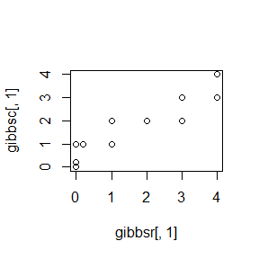

```r
set.seed(1)
library(Rcpp)
library(microbenchmark)
#write Rcpp function
cppFunction(' NumericMatrix gibbsC(int N,int n,int a,int b) {
      NumericMatrix X(N,2);
     X(0,0)=0.2;
     X(0,1)=0.3;
     for(int i = 1; i < N; i++) {
      double y = X(i-1, 1);
      X(i, 0) = rbinom(1,n,y)[0];
      double x = X(i, 0);
      X(i, 1) = rbeta(1,x+a,n-x+b)[0];
  }
      return X;
    }')

#R function
gibbsR<-function(N,n,a,b){
  X <- matrix(0, N, 2)
  X[1, ] <- c(0.2, 0.3) #initialize
  for (i in 2:N) {
   y <- X[i-1, 2]
   X[i, 1] <- rbinom(1,n,y)
   x <- X[i, 1]
   X[i, 2] <- rbeta(1,x+a,n-x+b)
  }
  X
}

N<-1000
a<-2;b<-3;n<-4

gibbsr=gibbsR(N,n,a,b)
gibbsc=gibbsC(N,n,a,b)

qqplot(gibbsr[,1],gibbsc[,1])
```

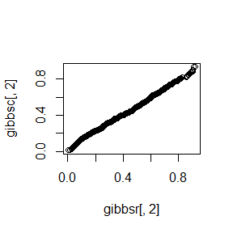

```r
qqplot(gibbsr[,2],gibbsc[,2])
```

```r
ts <- microbenchmark(gibbsr=gibbsR(N,n,a,b),
gibbsc=gibbsC(N,n,a,b))

summary(ts)[,c(1,3,5,6)]
```

```
##     expr      lq  median      uq
## 1 gibbsr 3905.60 4230.35 4458.55
## 2 gibbsc  325.65  334.65  367.55
```

By qqplot, we can see that the generated random numbers by C++ and R are coincident.The computation time of gibbsC is much less than gibbsR.